# Introducción al Lenguaje R

Santiago Benitez-Vieyra

## Regresión lineal múltiple e interacciones

### Modelos de múltiples variables independientes

- La interpretación de los parámetros se complica, particularmente si existen interacciones.
- Existen distintas maneras de incorporar las variables al modelo, en particular ¿las variables independientes tiene un efecto secuencial o simultáneo?
- Existen nuevos problemas para el buen ajuste del modelo, especialmente la colinearidad.
- ¿Cómo elijo el mejor modelo para mis datos? ¿debo predecir o explicar un patrón?

[output not shown]

```r
fit <- lm(Y ~ A + B + C, data = Datos)
summary(fit)

Call:
lm(formula = Y ~ A + B + C, data = Datos)

Residuals:
Min 1Q Median 3Q Max
-23.11973 -3.91218 -0.00486 3.42803 20.64737

Coefficients:
              Estimate   Std. Error   t value    Pr(>|t|)
(Intercept) -27.67413    5.89520       -4.694    7.69e-06 ***
A             0.31502    0.01917       16.430  < 2e-16 ***
B             7.77330    1.44922        5.364    4.49e-07 ***
C            -1.25652    0.96565       -1.301    0.196
---
Signif. codes: 0 '***' 0.001 '**' 0.01 '*' 0.05 '.' 0.1 ' ' 1
Residual standard error: 6.084 on 111 degrees of freedom
Multiple R-squared: 0.7634, Adjusted R-squared: 0.757
F-statistic: 119.4 on 3 and 111 DF, p-value: < 2.2e-16
```

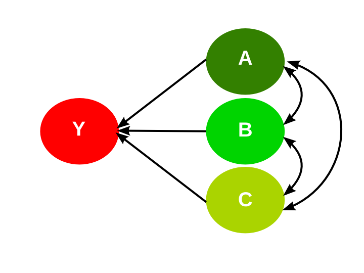

- El **intercepto** ($\beta_{0}$) se interpreta como el valor de la variable dependiente (y) cuando todas las variables independientes ($x$) toman un valor de 0.
- El **coeficiente regresión parcial** ($\beta_{1}$) es la pendiente de $y$ en $x_{1}$, mide el cambio en y por cada unidad de cambio en $x_{1}$, manteniendo los valores de las demás $x$ ($x_{2}$, $x_{3}$, etc.) constantes.
- $\beta_{1}$ mide los efectos directos de $x_{1}$ sobre $y$, descontando los efectos indirectos debidos a la correlación entre $x_{1}$ y las otras variables $x$ incluidas en el modelo.
- Los coeficientes parciales pueden contener efectos indirectos de variables no incluidas en el modelo.
- El $R^2$ no aumenta linealmente porque solo incluye la variación debida a los efectos directos.

### Interacciones

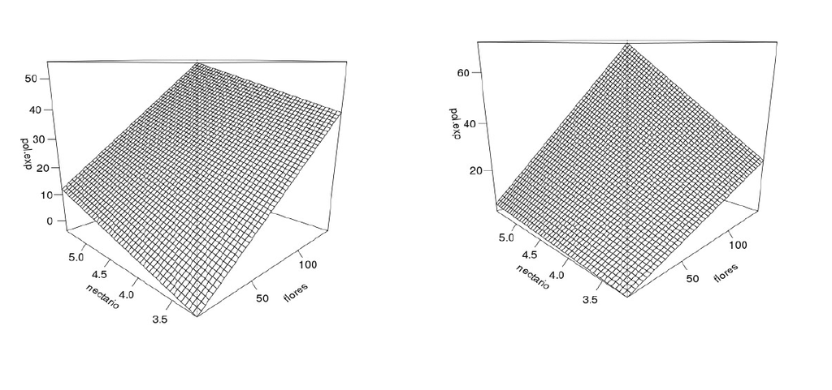

### Sumas de Cuadrados. Tipo 1.

```r
set.seed(123); a <- rnorm(100); b <- a+0.1 + rnorm(100) #simulacion
y <- 0.3*a + 0.3*b + 0.2*a*b + rnorm(100)               #simulacion
fit <- lm(y ~ a*b)
anova(fit)
```

```
## Analysis of Variance Table
##
## Response: y
##           Df Sum Sq Mean Sq F value    Pr(>F)
## a          1 17.986 17.9860  20.483 1.725e-05 ***
## b          1  7.577  7.5769   8.629  0.004142 **
## a:b        1 21.291 21.2912  24.247 3.521e-06 ***
## Residuals 96 84.296  0.8781
## ---
## Signif. codes:  0 '***' 0.001 '**' 0.01 '*' 0.05 '.' 0.1 ' ' 1
```

| Suma de Cuadrados | Descripción | A favor | En contra |
| --- | --- | --- | --- |
| Tipo I | Las variables son añadidas una a una, en el orden indicado en la fórmula. | No subestima la suma de cuadrados total. Preferible en modelos anidados donde hay un orden natural. | Distinto orden de los factores produce distintos resultados. |

### Sumas de Cuadrados. Tipo 2.

```r
set.seed(123); a <- rnorm(100); b <- a+0.1 + rnorm(100) #simulacion
y <- 0.3*a + 0.3*b + 0.2*a*b + rnorm(100)               #simulacion
library(car); Anova(fit, type = 2)
```

```
## Anova Table (Type II tests)
##
## Response: y
##           Sum Sq Df F value    Pr(>F)
## a          1.750  1  1.9932  0.161245
## b          7.577  1  8.6290  0.004142 **
## a:b       21.291  1 24.2473 3.521e-06 ***
## Residuals 84.296 96
## ---
## Signif. codes:  0 '***' 0.001 '**' 0.01 '*' 0.05 '.' 0.1 ' ' 1
```

| Suma de Cuadrados | Descripción | A favor | En contra |
| --- | --- | --- | --- |
| Tipo II | Cada término es testeado después de introducir todos los otros, excepto las interacciones | Modelo muy usado, especialmente cuando no hay interacciones. El orden no importa. | Es sensible al desbalanceo. |

### Sumas de Cuadrados. Tipo 3.

```r
set.seed(123); a <- rnorm(100); b <- a+0.1 + rnorm(100) #simulacion
y <- 0.3*a + 0.3*b + 0.2*a*b + rnorm(100)               #simulacion
library(car); Anova(fit, type = 3)
```

```
## Anova Table (Type III tests)
##
## Response: y
##             Sum Sq Df F value    Pr(>F)
## (Intercept)  0.053  1  0.0602 0.8066804
## a            0.519  1  0.5907 0.4440530
## b           11.072  1 12.6089 0.0005968 ***
## a:b         21.291  1 24.2473 3.521e-06 ***
## Residuals   84.296 96
## ---
## Signif. codes:  0 '***' 0.001 '**' 0.01 '*' 0.05 '.' 0.1 ' ' 1
```

| Suma de Cuadrados | Descripción | A favor | En contra |
| --- | --- | --- | --- |
| Tipo III | Cada término es testeado después de introducir todos los otros, incluso las interacciones. | No depende del tamaño de las celdas, útil en caso de desbalanceo. | Da la misma importancia a los efectos principales y a las interacciones. |

### Interacciones en el ANOVA

```r
set.seed(456); A = c(rep(0, 100), rep(1, 100)); B = rep(c(rep(0, 50), rep(1, 50)), 2)
y = 10 + 0.08*A - 0.03*B - 1.8*A*B + rnorm(200, 0, sd=1.8)
datos = data.frame(fat = y, age = as.factor(c(rep("young", 100), rep("old", 100))), breed = as.factor(rep(c(rep("jersey", 50), rep("canadian", 50)), 2)))
model = lm(fat ~ age*breed, data=datos)
library(car)
Anova(model, Type = 2)
```

```
## Anova Table (Type II tests)
##
## Response: fat
##           Sum Sq  Df F value    Pr(>F)
## age        77.76   1  24.417 1.659e-06 ***
## breed      45.65   1  14.334 0.0002034 ***
## age:breed  34.36   1  10.790 0.0012089 **
## Residuals 624.22 196
## ---
## Signif. codes:  0 '***' 0.001 '**' 0.01 '*' 0.05 '.' 0.1 ' ' 1
```

### Interacciones en el ANOVA

```r
set.seed(456); A = c(rep(0, 100), rep(1, 100)); B = rep(c(rep(0, 50), rep(1, 50)), 2)
y = 10 + 0.08*A - 0.03*B - 1.8*A*B + rnorm(200, 0, sd=1.8)
datos = data.frame(fat = y, age = as.factor(c(rep("young", 100), rep("old", 100))), breed = as.factor(rep(c(rep("jersey", 50), rep("canadian", 50)), 2)))
model = lm(fat ~ age*breed, data=datos)
summary(model)
```

```
##
## Call:
## lm(formula = fat ~ age * breed, data = datos)
##
## Residuals:
##     Min      1Q  Median      3Q     Max
## -4.2273 -1.3230 -0.0926  1.4443  3.8388
##
## Coefficients:
##                      Estimate Std. Error t value Pr(>|t|)
## (Intercept)            8.0627     0.2524  31.946  < 2e-16 ***
## ageyoung               2.0761     0.3569   5.817 2.41e-08 ***
## breedjersey            1.7845     0.3569   5.000 1.27e-06 ***
## ageyoung:breedjersey  -1.6580     0.5048  -3.285  0.00121 **
## ---
## Signif. codes:  0 '***' 0.001 '**' 0.01 '*' 0.05 '.' 0.1 ' ' 1
##
## Residual standard error: 1.785 on 196 degrees of freedom
## Multiple R-squared:  0.2018, Adjusted R-squared:  0.1895
## F-statistic: 16.51 on 3 and 196 DF,  p-value: 1.317e-09
```

### Interacciones en el ANOVA

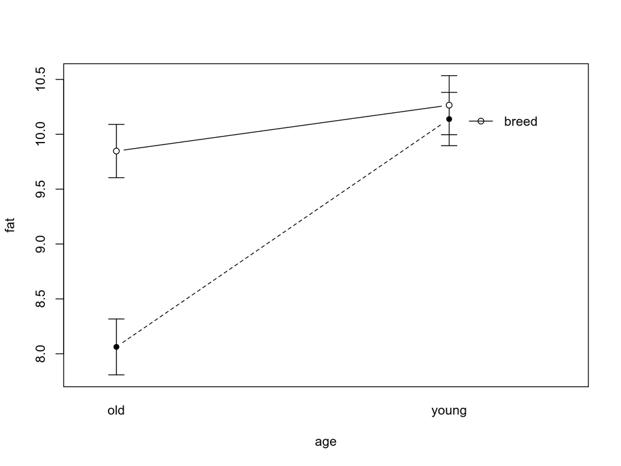

### Modelos lineales con interacción

```r
fit <- lm(Y ~ X * Z) # X es un CONTINUA, Z es FACTOR (a,b,c)
summary(fit)
---
Coefficients:
            Estimate  Std. Error t value  Pr(>|t|)
(Intercept) 0.1078    0.3136     0.344    0.732958
X           0.9714    0.2561     3.793    0.000505 ***
Zb          2.6422    0.4435     5.957    5.94e-07 ***
Zc          0.2278    0.4435     0.514    0.610429
X:Zb       -1.5674    0.3622    -4.328    0.000101 ***
X:Zc       -0.7103    0.3622    -1.961    0.057013 .
---
```

$$y = \beta_{0} + \beta_{1}X + \beta_{2}d_{1} + \beta_{3}d_{2} + \beta_{4}Xd_{1} + \beta_{5}Xd_{2} + \epsilon$$

$$y = \beta_{0} + \beta_{1}X + \beta_{2}d_{1} + \beta_{3}d_{2} + \beta_{4}Xd_{1} + \beta_{5}Xd_{2} + \epsilon$$

- Para el nivel a: $y = \beta_{0} + \beta_{1}X$
- Para el nivel b: $y = \beta_{0} + \beta_{2}d_{1} + \beta_{1}X + \beta_{4}Xd_{1}$
- Para el nivel c: $y = \beta_{0} + \beta_{3}d_{2} + \beta_{1}X + \beta_{5}Xd_{2}$

$$y = \beta_{0} + \beta_{1}X + \beta_{2}d_{1} + \beta_{3}d_{2} + \beta_{4}Xd_{1} + \beta_{5}Xd_{2} + \epsilon$$

- Para el nivel a: $y = 0.1078 + 0.9714 X$
- Para el nivel b: $y = (0.1078 + 2.6422) + (0.9714Z - 1.5674)X$
- Para el nivel c: $y = (0.1078 + 0.2278) + (0.9714Z - 0.7103)X$

### Modelos lineales con interacción

```r
fit <- lm(Y ~ X * Z) # X es un CONTINUA, Z es FACTOR (a,b,c)
summary(fit)
---
Coefficients:
            Estimate  Std. Error t value  Pr(>|t|)
(Intercept) 0.1078    0.3136     0.344    0.732958
X           0.9714    0.2561     3.793    0.000505 ***
Zb          2.6422    0.4435     5.957    5.94e-07 ***
Zc          0.2278    0.4435     0.514    0.610429
X:Zb       -1.5674    0.3622    -4.328    0.000101 ***
X:Zc       -0.7103    0.3622    -1.961    0.057013 .
---
```

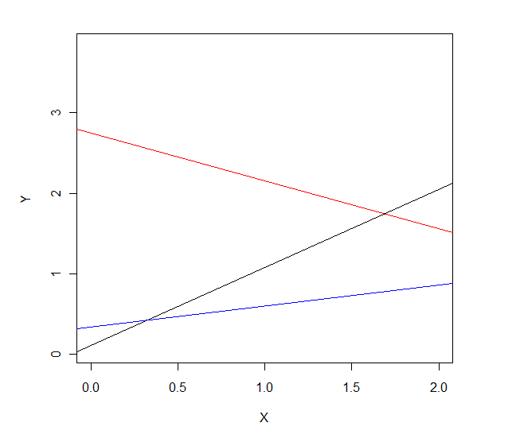

### ANCOVA y Regresión con variable dummy.

- ¿Tienen igual pendiente las líneas de regresión bajo distintos tratamientos? Es decir, ¿es significativa la interacción?
- ¿Puedo reducir la variación residual en mi experimento si tomo en cuenta la variación debida a una variable continua (ANCOVA) o a una variable categórica (regresión con dummy)?

> Según la pregunta de interés se decide la presentación del resultado.